# Churn_Prediction

## **Churn Prediction with ML**

*Author:* Aybike Dilek

*Date:* 12.06.2021

**Project Definition**

The project aims to conduct various exploratory analyses and machine learning applications. The churn prediction will be the main topic of the machine learning algorithms. The algorithms will be compared according to evaluation metrics.

**About Dataset**

The data set contains the various attributes of the telecom customers. It is the combination of 100 columns with 100 thousand records. The target variable is the churn column. It will be accepted as 0 represents non-churn and 1 represents churn customers. Since 100 columns are quite higher, it is not explained in this part. The details of the columns can be obtained from the **Appendix**.

**Literature Review**

**Overview**

The packages were imported. The **pandas** and the **numpy** were used for data processing such as filtering, sorting, subsetting. The **matplotlib** and the **seaborn** were used for visualization. The **warnings** was used for hiding warning messages. The **skew** was used to check the skewness hypothesis.

```python
import pandas as pd
import numpy as np
import matplotlib.pyplot as plt
import seaborn as sns
import warnings
from scipy.stats import skew
from google.colab import files
uploaded = files.upload()
```

Upload widget is only available when the cell has been executed in the current browser session. Please rerun this cell to enable.

```
Saving Telecom_customer churn.csv to Telecom_customer churn.csv
```

The dataset was imported and the columns were investigated.

```python
data=pd.read_csv("Telecom_customer churn.csv")
print(data.info())
```

```
<class 'pandas.core.frame.DataFrame'>
RangeIndex: 100000 entries, 0 to 99999
Data columns (total 100 columns):
 #   Column            Non-Null Count   Dtype
---  ------            --------------   -----
 0   rev_Mean          99643 non-null   float64
 1   mou_Mean          99643 non-null   float64
 2   totmrc_Mean       99643 non-null   float64
 3   da_Mean           99643 non-null   float64
 4   ovrmou_Mean       99643 non-null   float64
 5   ovrrev_Mean       99643 non-null   float64
 6   vceovr_Mean       99643 non-null   float64
 7   datovr_Mean       99643 non-null   float64
 8   roam_Mean         99643 non-null   float64
 9   change_mou        99109 non-null   float64
```

[output cut: 93 more lines]

**Preprocessing**

*The **child_flag** was derived manually. It explained that whether a child lives in a household or not. The age bins of the kids were used such as kid0_2, kid3_5, kid6_10, and others.*

```python
data.kid0_2.replace(['Y', 'U',''], [1, 0 , ''], inplace=True)
data.kid3_5.replace(['Y', 'U',''], [1, 0 , ''], inplace=True)
data.kid6_10.replace(['Y','U',''], [1,  0 , ''], inplace=True)
data.kid11_15.replace(['Y', 'U',''], [1,  0 , ''], inplace=True)
data.kid16_17.replace(['Y', 'U',''], [1,  0 , ''], inplace=True)
data['child_num']=data['kid0_2']+data['kid3_5']+data['kid6_10']+data['kid11_15']+data['kid16_17']
warnings.filterwarnings('ignore')
condition_one = (data["child_num"] >0)
condition_two = (data["child_num"] ==0)
conditions = [condition_one, condition_two]
choices = ["1", "0"]
data["child_flag"] = np.select(conditions, choices, default="")
data["child_flag"] = pd.to_numeric(data["child_flag"])
```

The used columns were dropped from the dataset to avoid overfitting.

```python
data= data.drop(['kid0_2'], axis=1)
data= data.drop(['kid3_5'], axis=1)
data= data.drop(['kid6_10'], axis=1)
data= data.drop(['kid11_15'], axis=1)
data= data.drop(['kid16_17'], axis=1)
data= data.drop(['child_num'], axis=1)
```

Some of the string values were transformed to numeric values to be used in the machine learning steps.

```python
data.new_cell.replace(['Y', 'N','U',''], [1, 0, 0 , ''], inplace=True)
data.asl_flag.replace(['Y', 'N',''], [1, 0,''], inplace=True)
data.creditcd.replace(['Y', 'N',''], [1, 0,''], inplace=True)
```

It was observed that some columns contain missing values like numbcars, dwllsize. The column, which had a higher than **%45** missing value ratio, was filtered out.

```python
data.columns[data.isnull().mean() > 0.45]
```

```
Index(['numbcars'], dtype='object')
```

```python
data= data.drop(['numbcars'], axis=1)
```

It was checked that the columns were filtered out correctly.

```python
data.shape
```

```
(100000, 95)
```

*Some of the records must be filled or removed before the machine learning applications according to the needs because of the missing values. This step will be done in the following parts based on column distributions, which will be shown in the **Descriptive Analyses** part.*

Besides, **drop_duplicates** had been made to make sure that there were no duplicate rows in the dataset.

```python
data= data.drop_duplicates()
```

**Descriptive Analysis**

The histogram charts of the numeric columns were displayed.

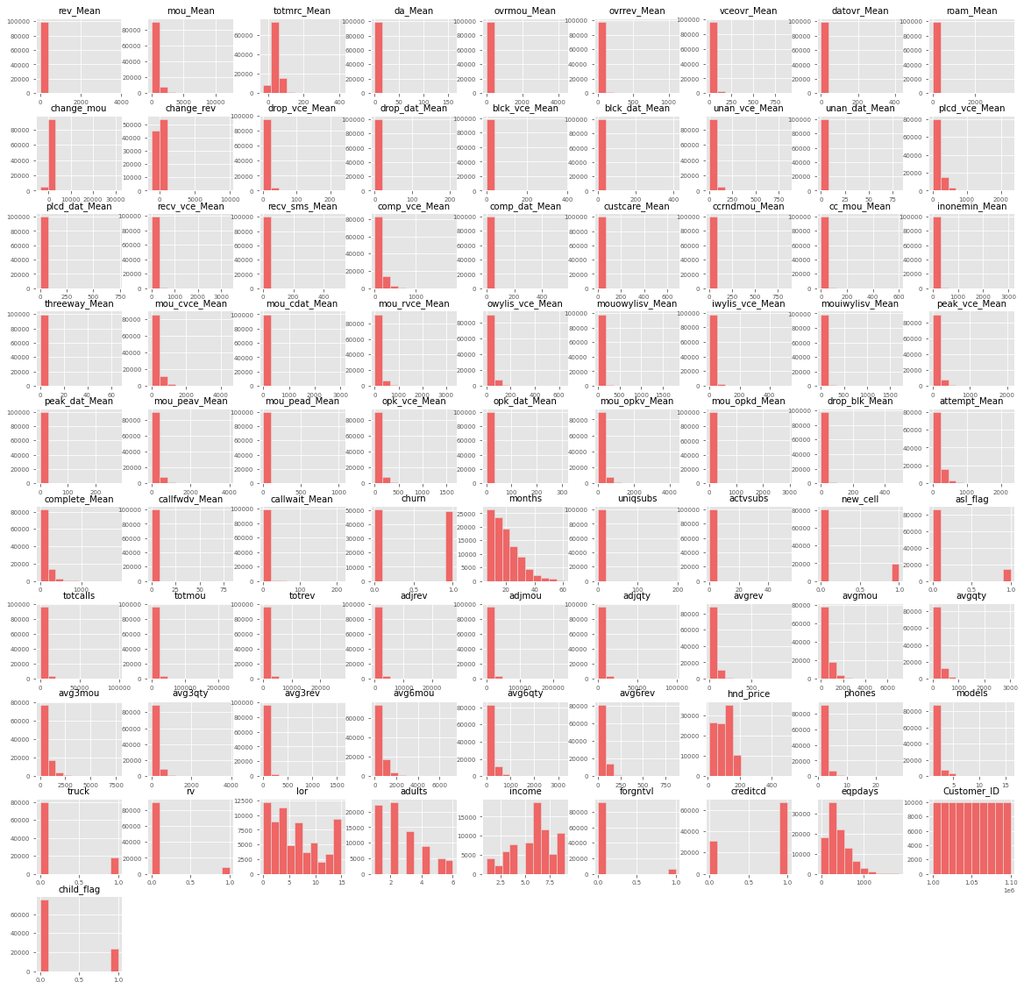

```python
#The numeric columns were selected.
num_col=data.select_dtypes(include=np.number).columns.tolist()
plt.style.use('ggplot')
plt.rcParams.update({'font.size': 7})
data[num_col].hist(figsize=(20, 20),color="#EE6666",edgecolor='#E6E6E6')
plt.show()
```

It was seen that there were binary variables. Also, months and eqpdays columns had nearly the **Skewed Right Distribution**.

The skewness hypothesis of the two columns was checked.

```python
for i in ["eqpdays","months"]:
  print(str(i)+': '+ str(round(data[i].skew(skipna = True),4)))
```

```
eqpdays: 1.044
months: 1.0603
```

Since, **Skewness > 0** for the columns, we can say that months and eqpdays columns had right-skewed distribution statistically.

The summary of the columns was displayed.

```python
print(data[num_col].describe().round())
```

```
       rev_Mean  mou_Mean  totmrc_Mean  ...  eqpdays  Customer_ID  child_flag
count   99643.0   99643.0      99643.0  ...  99999.0     100000.0     98268.0
mean       59.0     514.0         46.0  ...    392.0    1050000.0         0.0
std        46.0     525.0         24.0  ...    256.0      28868.0         0.0
min        -6.0       0.0        -27.0  ...     -5.0    1000001.0         0.0
25%        33.0     151.0         30.0  ...    212.0    1025001.0         0.0
50%        48.0     356.0         45.0  ...    342.0    1050000.0         0.0
75%        71.0     703.0         60.0  ...    530.0    1075000.0         0.0
max      3843.0   12207.0        410.0  ...   1823.0    1100000.0         1.0

[8 rows x 82 columns]
```

It was seen that **eqpdays** had some unreliable records like -5. The number of days (age) of current equipment could not be negative. Thus, unreliable records were filtered out. This situation was the same for the mean monthly revenue (charge amount) and mean total monthly recurring charge.

```python
data=data[data["eqpdays"]>=0]
data=data[data["rev_Mean"]>=0]
data=data[data["totmrc_Mean"]>=0]
```

```python
data.shape
```

```
(99484, 95)
```

After the filter process, the summary of the columns was displayed again to check the dataset.

```python
print(data[num_col].describe().round())
```

```
       rev_Mean  mou_Mean  totmrc_Mean  ...  eqpdays  Customer_ID  child_flag
count   99484.0   99484.0      99484.0  ...  99484.0      99484.0     97763.0
mean       59.0     513.0         46.0  ...    392.0    1049905.0         0.0
std        46.0     524.0         24.0  ...    255.0      28802.0         0.0
min         0.0       0.0          0.0  ...      0.0    1000001.0         0.0
25%        33.0     151.0         30.0  ...    212.0    1024969.0         0.0
50%        48.0     355.0         45.0  ...    342.0    1049926.0         0.0
75%        71.0     702.0         60.0  ...    529.0    1074842.0         0.0
max      3843.0   12207.0        410.0  ...   1823.0    1099994.0         1.0

[8 rows x 82 columns]
```

The box plot of the **eqpdyas** was displayed.

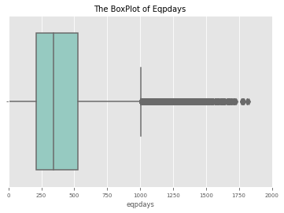

```python
ax = sns.boxplot(x="eqpdays",
                 data=data,palette="Set3")
plt.title("The BoxPlot of Eqpdays",fontsize="10")
plt.xlim(0,2000)
plt.show()
```

It was seen that the eqpdays column had outlier values. The median values were used in the EDA part to avoid the effect of the outliers.

**Exploratory Data Analysis**

**Analysis 1:**

```python
data.pivot_table(index='churn',
                    aggfunc={'eqpdays':'median','totrev':'median','complete_Mean' : 'median',
                             'totmrc_Mean':'median', 'attempt_Mean': 'median','mou_Mean':'median'}).round()
```

| churn | attempt_Mean | complete_Mean | eqpdays | mou_Mean | totmrc_Mean | totrev |
| --- | --- | --- | --- | --- | --- | --- |
| 0 | 107.0 | 81.0 | 310.0 | 380.0 | 45.0 | 784.0 |
| 1 | 95.0 | 72.0 | 366.0 | 330.0 | 43.0 | 824.0 |

It was seen that the median values of the eqpdays variated between churn and non-churn customers. The median eqpdays value of the churn customers was higher than non-churn customers. The non-churn customers had a higher median value for the attempt and complete mean time. The median pay amount of churn customers was higher than non-churn customers according to the totrev value. The median value of the mean number of monthly minutes of use was higher for non-churn customers compared to the churn customers. There was not a significant difference between churn and non-churn customers in terms of a mean total monthly recurring charge.

**Analysis 2:**

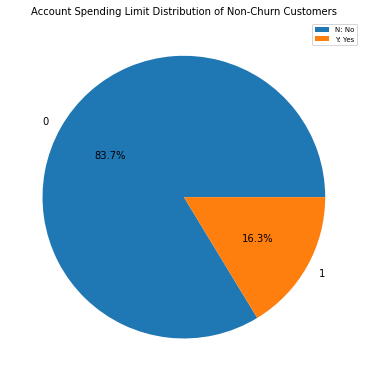

```python
SET_1=data[data["churn"]==0].groupby('asl_flag')['Customer_ID'].count()
plt.figure(figsize=(6.5, 6.5), edgecolor='w')
plt.style.use('default')
SET_1.plot(kind='pie',autopct='%1.1f%%')
plt.title("Account Spending Limit Distribution of Non-Churn Customers",fontsize=10)
plt.legend(["N: No","Y: Yes"],loc='upper right',fontsize=7)
plt.ylabel('')
plt.show()
```

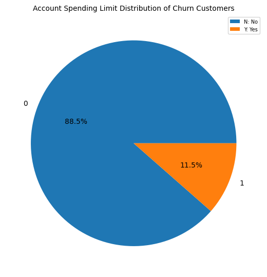

```python
SET_2=data[data["churn"]==1].groupby('asl_flag')['Customer_ID'].count()
plt.figure(figsize=(6.5, 6.5), edgecolor='w')
plt.style.use('default')
SET_2.plot(kind='pie',autopct='%1.1f%%')
plt.title("Account Spending Limit Distribution of Churn Customers",fontsize=10)
plt.legend(["N: No","Y: Yes"],loc='upper right',fontsize=7)
plt.ylabel('')
plt.show()
```

It was seen that the yes percentage of the churn customers was less than non-churn customers. In the first analyses, the median totrev (pay amount) value of the churn customers was higher than non-churn customers. They could be related. Churn customers may be paying more because they do not use the account spending limit feature. It can be a reason for the churn action. Besides, it can be concluded from this analysis that the overall usage of the feature is low.

**Analysis 3:**

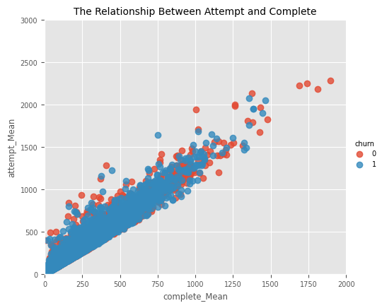

```python
plt.style.use('ggplot')
plt.rcParams.update({'font.size': 7})
SET_3=data
sns.lmplot(x="complete_Mean", y="attempt_Mean", data=SET_3, fit_reg=False, hue='churn', legend=True, height=4, aspect=1.2)
plt.title("The Relationship Between Attempt and Complete",fontsize="10")
plt.ylim(0,3000)
plt.xlim(0,2000)
plt.show()
```

```python
r = np.corrcoef(SET_3.attempt_Mean, SET_3.complete_Mean)
print(round(r[0,1],2))
```

```
0.99
```

In this part, it was investigated that the amount of the relationship between the attempt and complete. Besides, the Pearson correlation coefficient was displayed. It was seen that they were highly correlated. There were other columns, which had the same situation. According to this analysis, some features had muli-colinearity in the dataset. Thus, to reduce the impact of this situation, it was decided to implement the **PCA** in machine learning steps.

**Analysis 4:**

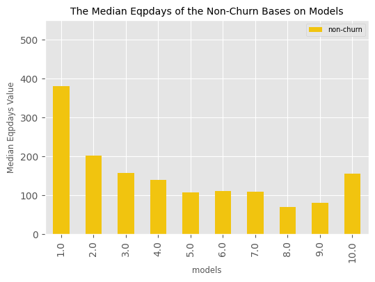

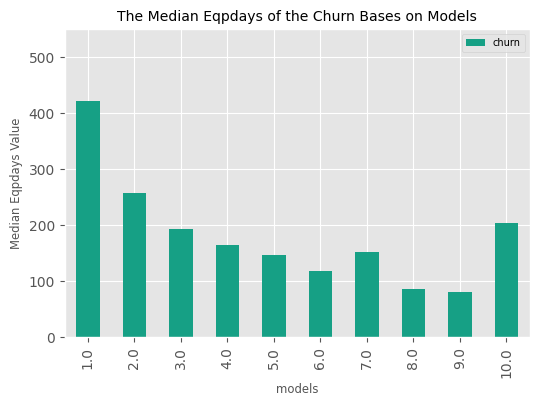

```python
SET_4=data[np.logical_and(data["churn"]==0,data["models"]<=10)].groupby('models').agg({"eqpdays": "median"}).sort_values(["models"],ascending=True)
SET_5=data[np.logical_and(data["churn"]==1,data["models"]<=10)].groupby('models').agg({"eqpdays": "median"}).sort_values(["models"],ascending=True)
SET_4.plot(kind="bar",title="The Median Eqpdays of the Non-Churn Bases on Models",fontsize=10,color="#F1C40F",figsize=(6, 4))
plt.ylabel("Median Eqpdays Value")
plt.ylim(0,550)
plt.legend(["non-churn"])
SET_5.plot(kind="bar",title="The Median Eqpdays of the Churn Bases on Models",fontsize=10,color="#16A085",figsize=(6, 4))
plt.ylabel("Median Eqpdays Value")
plt.ylim(0,550)
plt.legend(["churn"])
plt.show()
```

The churn customers had a higher median age of current equipment nearly in each model batch than non-churn customers. The one model issued had the highest median age of current equipment for both customers. The median age of current equipment decreased when the number of models issued increased, except ten, for both customers. From this, it can be concluded that churn customers use the models for a longer period than non-churn customers. Besides, the reason for the small fluctuations in the distribution after the number of models exceeded five may be that some people buy phones that they do not use on their own. In this case, even if the number of models appears to be 10, not all of them belong to one person.

Only the at most ten models issued were shown. It was seen that when the number of models issued passed ten, the unreliable values came up. Thus, the number of models issued was filtered out after ten.

```python
data=data[data["models"]<=10]
```

```python
print(data.shape)
```

```
(99478, 95)
```

**Analysis 5:**

```python
SET_6=data[data["new_cell"]!='U']
SET_6.pivot_table(index='new_cell', columns='churn',
                    aggfunc={'eqpdays':'median',
                             'hnd_price' : 'median',
                             'complete_Mean' : 'median',
                             'drop_blk_Mean':'median'}).round(2).rename_axis(
                        index={'new_cell': 'New Cell Phone User'})
```

| churn New Cell Phone User | complete_Mean 0 | complete_Mean 1 | drop_blk_Mean 0 | drop_blk_Mean 1 | eqpdays 0 | eqpdays 1 | hnd_price 0 | hnd_price 1 |
| --- | --- | --- | --- | --- | --- | --- | --- | --- |
| 0 | 80.33 | 71.0 | 5.67 | 5.33 | 309.0 | 361.0 | 129.99 | 99.99 |
| 1 | 85.33 | 73.0 | 6.00 | 5.33 | 314.0 | 389.0 | 99.99 | 79.99 |

**Analysis 6:**

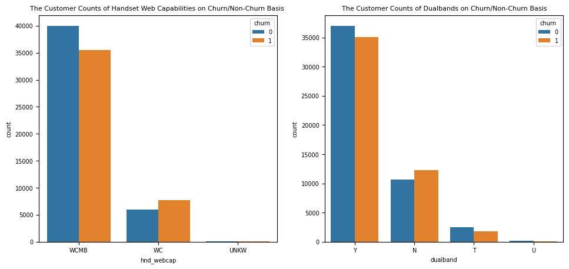

```python
SET_7=data
plt.style.use('default')
plt.rcParams.update({'font.size': 7})
fig, ax =plt.subplots(1,2,figsize=(11.5,5))
sns.countplot(x="hnd_webcap", hue="churn", data=data, ax=ax[0])
ax[0].set_title("The Customer Counts of Handset Web Capabilities on Churn/Non-Churn Basis ",fontsize=8)
sns.countplot(x="dualband", hue="churn", data=SET_6, ax=ax[1])
ax[1].set_title("The Customer Counts of Dualbands on Churn/Non-Churn Basis",fontsize=8)
plt.show()
```

Handset Web Capability has three levels; “web-capable mini-browser”, “web capability”, and “unknown”. It was seen that the WC category of the Handset web capability had more churn customers than non-churn customers. It is the middle category of the Handset web capability. It was similar for the dualband. Dualband has four levels; “no dualband”, “dualband”, “tri-model (analog, digital, 3G)”, and “unknown”. Category N had more churn customers than non-churn customers. It is the lowest category of Dualband.

**Analysis 7:**

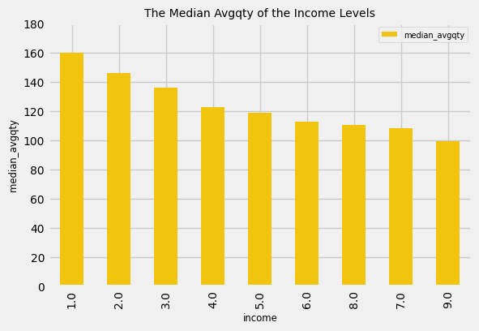

```python
SET_8=data.groupby('income').agg({"avgqty": "median"}).sort_values(["avgqty"],ascending=False)
plt.style.use('fivethirtyeight')
plt.rcParams.update({'font.size': 7})
SET_8.plot(kind="bar",title="The Median Avgqty of the Income Levels",fontsize=10,color="#F1C40F",figsize=(6, 4),
           label="median_avgqty")
plt.ylabel("median_avgqty")
plt.legend(["median_avgqty"],loc ="upper right")
plt.ylim(0,180)
plt.show()
```

It was seen that when the income level increased the median value of the average monthly number of calls over the life of the customers decreased, except 7 and 8. This may be because the accessibility of customers decreases as the income level rises. Also, the fact that people with increased income get support from different people for call traffic and use more than one line may have caused this situation.

**Machine Learning Models**

The supervised and unsupervised techniques were used in the study. It was seen that there was multi-linearity between some of the columns such as complete_Mean and attempt_Mean in the EDA phase. First of all, the PCA was applied to reduce multi-collinearity and avoid overfitting. Then, some of the supervised classification techniques were applied.

1. **Naive Bayes**
2. **Support Vector Machine Classification**
3. **Decision Tree Classification**
4. **Random Forest Classification**
5. **AdaBoost Classifier**
6. **XGBoost Classifier**

*The SVM Classification was not tried for each kernel type because of the time consumption of the models. The only linear kernel was tried.*

Besides, the **Train set – Test set split** was used to develop and test the machine learning models. The **GridSearch** was used for parameter tuning for some of the machine learning models. Lastly, the **Confusion Matrix**, **Accuracy Score** and **Classification Report** were used for benchmarking the machine learning models.

**PCA Application**

First of all, the PCA was applied to reduce multi-collinearity and avoid overfitting.

The data_num had missing values. That is why the missing values were filled before the PCA. Since the columns had not a normal distribution, a median strategy was preferred. The missing churn observations were directly removed instead of filling.

```python
data_num=data[num_col]
data_num=data_num.dropna(subset=['churn'])
data_num=data_num.fillna(data_num.median())
```

As mentioned in the **Descriptive Analysis** part, the binary variables were detected. The PCA was applied to the continuous variables. That is why the binary variables were listed and filtered out.

```python
list_col=[]
for col in data_num.columns:
    list_col.append(col)
print(list_col)
```

```
['rev_Mean', 'mou_Mean', 'totmrc_Mean', 'da_Mean', 'ovrmou_Mean', 'ovrrev_Mean', 'vceovr_Mean', 'datovr_Mean', 'roam_Mean', 'change_mou', 'change_rev', 'drop_vce_Mean', 'drop_dat_Mean', 'blck_vce_Mean', 'blck_dat_Mean', 'unan_vce_Mean', 'unan_dat_Mean', 'plcd_vce_Mean', 'plcd_dat_Mean', 'recv_vce_Me…
```

```python
df = pd.DataFrame(data_num)
bool_cols = [col for col in df
             if np.isin(df[col].dropna().unique(), [0, 1]).all()]
bool_cols
```

```
['churn',
 'new_cell',
 'asl_flag',
 'truck',
 'rv',
 'forgntvl',
 'creditcd',
 'child_flag']
```

```python
data_num_2 = data_num
for i in bool_cols:
  data_num_2= data_num_2.drop([i], axis=1)

data_num_2.shape
```

```
(99478, 74)
```

Also, there were discrete variables. They were filtered out. They were detected from histogram analysis and examinations.

```python
list_discrete = ['phones','models','adults','income','Customer_ID','uniqsubs','months','lor','eqpdays','actvsubs','adjqty','totcalls']
```

```python
for i in list_discrete:
  data_num_2= data_num_2.drop([i], axis=1)

data_num_2.shape
```

```
(99478, 62)
```

The Min-Max scaling process was done before the PCA application.

```python
from sklearn.preprocessing import MinMaxScaler
scaler = MinMaxScaler()
data_num_2 = scaler.fit_transform(data_num_2)
```

The number of components was selected according to the explained variance.

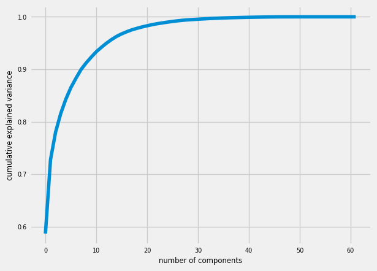

```python
from sklearn.decomposition import PCA
pca = PCA().fit(data_num_2)
plt.plot(np.cumsum(pca.explained_variance_ratio_))
plt.xlabel('number of components')
plt.ylabel('cumulative explained variance');
```

It was seen that 7 components would explain nearly 90% of the variance.

```python
pca = PCA(n_components=7)
pca.fit(data_num_2)
data_num_2_pca = pca.transform(data_num_2)
print("original shape:   ", data_num_2.shape)
print("transformed shape:", data_num_2_pca.shape)
```

```
original shape:    (99478, 62)
transformed shape: (99478, 7)
```

As the PCA was applied, filtered out discrete and binary variables were added to the transformed data frame. Since the dataset was not sorted, the order of the observations aligned directly.

```python
data_num_2_pca = pd.DataFrame( data_num_2_pca)
for i in bool_cols:
  data_num_2_pca[i]=(data_num[i])
```

```python
print(data_num_2_pca)
```

```
              0         1         2  ...  forgntvl  creditcd  child_flag
0     -0.128573  0.113451 -0.004205  ...       0.0       1.0         0.0
1      0.083128 -0.027063 -0.023128  ...       0.0       1.0         0.0
2     -0.213090 -0.122903  0.054202  ...       0.0       1.0         1.0
3     -0.238758 -0.114533  0.035693  ...       0.0       1.0         1.0
4      0.064820  0.085548  0.010160  ...       0.0       1.0         0.0
...         ...       ...       ...  ...       ...       ...         ...
99473  0.011656  0.205177  0.089733  ...       0.0       1.0         0.0
99474  0.115989 -0.168655  0.051146  ...       0.0       0.0         0.0
99475 -0.087900 -0.081075 -0.046791  ...       0.0       0.0         0.0
99476 -0.202736 -0.119409 -0.012239  ...       0.0       1.0         0.0
99477  0.458038  0.030613  0.000932  ...       0.0       0.0         0.0

[99478 rows x 15 columns]
```

```python
for i in list_discrete:
  data_num_2_pca[i]=(data_num[i])
```

```python
print(data_num_2_pca)
```

```
              0         1         2  ...  actvsubs   adjqty  totcalls
0     -0.128573  0.113451 -0.004205  ...       1.0   1602.0    1652.0
1      0.083128 -0.027063 -0.023128  ...       1.0  14624.0   14654.0
2     -0.213090 -0.122903  0.054202  ...       1.0   7888.0    7903.0
3     -0.238758 -0.114533  0.035693  ...       1.0   1479.0    1502.0
4      0.064820  0.085548  0.010160  ...       1.0   4452.0    4485.0
...         ...       ...       ...  ...       ...      ...       ...
99473  0.011656  0.205177  0.089733  ...       2.0   6643.0    6852.0
99474  0.115989 -0.168655  0.051146  ...       1.0    792.0     835.0
99475 -0.087900 -0.081075 -0.046791  ...       1.0   5246.0    5443.0
99476 -0.202736 -0.119409 -0.012239  ...       1.0    367.0     379.0
99477  0.458038  0.030613  0.000932  ...       1.0   1131.0    1209.0

[99478 rows x 27 columns]
```

```python
for i in list_discrete:
  data_num_2_pca[[i]]=scaler.fit_transform(data_num_2_pca[[i]])
```

```python
print(data_num_2_pca)
```

```
              0         1         2  ...  actvsubs    adjqty  totcalls
0     -0.128573  0.113451 -0.004205  ...  0.018868  0.016230  0.016708
1      0.083128 -0.027063 -0.023128  ...  0.018868  0.148159  0.148209
2     -0.213090 -0.122903  0.054202  ...  0.018868  0.079915  0.079930
3     -0.238758 -0.114533  0.035693  ...  0.018868  0.014984  0.015191
4      0.064820  0.085548  0.010160  ...  0.018868  0.045104  0.045361
...         ...       ...       ...  ...       ...       ...       ...
99473  0.011656  0.205177  0.089733  ...  0.037736  0.067302  0.069300
99474  0.115989 -0.168655  0.051146  ...  0.018868  0.008024  0.008445
99475 -0.087900 -0.081075 -0.046791  ...  0.018868  0.053148  0.055050
99476 -0.202736 -0.119409 -0.012239  ...  0.018868  0.003718  0.003833
99477  0.458038  0.030613  0.000932  ...  0.018868  0.011458  0.012228

[99478 rows x 27 columns]
```

The id column was removed to avoid the ordinal relationship.

```python
data_num_2_pca= data_num_2_pca.drop(['Customer_ID'], axis=1)
```

```python
print(data_num_2_pca.shape)
```

```
(99478, 26)
```

**Test Set & Train Set**

As the filling process was done for PCA features, the added columns had some missing values. The missing values were filled with the median value.

```python
data_num_2_pca=data_num_2_pca.fillna(data_num_2_pca.median())
```

First, the features and target were split.

```python
data_num_2_pca_features = data_num_2_pca.drop(['churn'], axis=1)
data_num_2_pca_target = data_num_2_pca['churn']
```

The balancing process was done before splitting.

```python
from imblearn.over_sampling import SMOTE
sm = SMOTE(sampling_strategy='auto', random_state=100)
data_num_2_pca_features,data_num_2_pca_target = sm.fit_sample(data_num_2_pca_features,data_num_2_pca_target)
```

Then, the test and train sets were split.

```python
from sklearn.model_selection import train_test_split
Xtrain, Xtest, ytrain, ytest = train_test_split(data_num_2_pca_features, data_num_2_pca_target,  test_size=0.35,
                                                random_state=42)
```

**Classification Models**

**Naive** **Bayes**

```python
from sklearn.naive_bayes import GaussianNB
model = GaussianNB()
model.fit(Xtrain, ytrain)
y_pred=model.predict(Xtest)
```

```python
from sklearn import metrics
print(metrics.classification_report(ytest,y_pred))
```

```
              precision    recall  f1-score   support

         0.0       0.56      0.53      0.54     17596
         1.0       0.55      0.58      0.57     17676

    accuracy                           0.56     35272
   macro avg       0.56      0.56      0.56     35272
weighted avg       0.56      0.56      0.56     35272
```

```python
y_pred_train=model.predict(Xtrain)
print(metrics.classification_report(ytrain,y_pred_train))
```

```
              precision    recall  f1-score   support

         0.0       0.56      0.53      0.54     32792
         1.0       0.55      0.58      0.57     32712

    accuracy                           0.55     65504
   macro avg       0.56      0.55      0.55     65504
weighted avg       0.56      0.55      0.55     65504
```

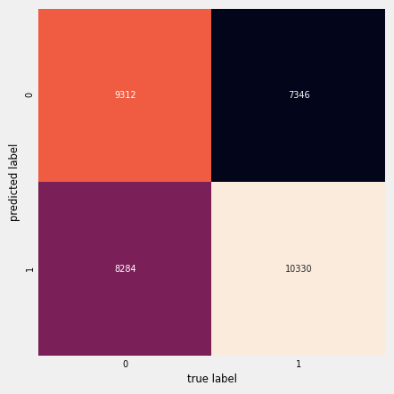

```python
from sklearn.metrics import confusion_matrix
import seaborn as sns
import matplotlib.pyplot as plt

mat = confusion_matrix(ytest,y_pred)
sns.heatmap(mat.T, square=True, annot=True, fmt='d', cbar=False)
plt.xlabel('true label')
plt.ylabel('predicted label')
plt.show()
```

The accuracy of the Naive Bayes was 0.56. Since the dataset was balanced, the accuracy score was used on the evaluation. The recall score was significantly different for churn and non-churn. The TN was low and the FP was high. Thus, it could cause this difference. This model was more prone to churn (1) predictions. This situation could cause weakness in the prediction power of non-churn (0).

**Support Vector** **Machine**

```python
from sklearn.svm import SVC
from sklearn.model_selection import GridSearchCV
tuned_parameters= {'kernel': ['linear'],
                    'C':[10,100]}
grid=GridSearchCV(SVC(),tuned_parameters,cv=3)
grid.fit(Xtrain, ytrain)
print(grid.best_params_)
model=grid.best_estimator_
y_pred=model.predict(Xtest)
```

```
{'C': 100, 'kernel': 'linear'}
```

```python
print(metrics.classification_report(ytest,y_pred))
```

```
              precision    recall  f1-score   support

         0.0       0.58      0.40      0.48     17596
         1.0       0.54      0.71      0.62     17676

    accuracy                           0.56     35272
   macro avg       0.56      0.56      0.55     35272
weighted avg       0.56      0.56      0.55     35272
```

```python
y_pred_train=model.predict(Xtrain)
print(metrics.classification_report(ytrain,y_pred_train))
```

```
              precision    recall  f1-score   support

         0.0       0.58      0.41      0.48     32792
         1.0       0.54      0.71      0.62     32712

    accuracy                           0.56     65504
   macro avg       0.56      0.56      0.55     65504
weighted avg       0.56      0.56      0.55     65504
```

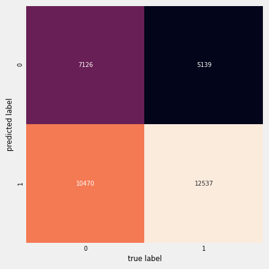

```python
mat = confusion_matrix(ytest,y_pred)
sns.heatmap(mat.T, square=True, annot=True, fmt='d', cbar=False)
plt.xlabel('true label')
plt.ylabel('predicted label')
plt.show()
```

As mentioned above, this model was run with the only linear kernel because of the computational cost of the models. The accuracy of the SVM model was 0.56 as Naive Bayes. This model provided worse recall outputs with given parameters compared to the Naive Bayes.

**Decision Tree Classification**

To avoid overfitting, the min_samples_split and min_samples_leaf values were changed and tried with Grid Search.

```python
from sklearn.tree import DecisionTreeClassifier
tuned_parameters= {'criterion': ['gini', 'entropy'],
                   'min_samples_split': [900,1100,1500],
                   'min_samples_leaf':[25,100,150]}
grid=GridSearchCV(DecisionTreeClassifier(),tuned_parameters,cv=3)
grid.fit(Xtrain, ytrain)
print(grid.best_params_)
model=grid.best_estimator_
y_pred=model.predict(Xtest)
```

```
{'criterion': 'gini', 'min_samples_leaf': 150, 'min_samples_split': 1500}
```

```python
print(metrics.classification_report(ytest,y_pred))
```

```
              precision    recall  f1-score   support

         0.0       0.60      0.58      0.59     17596
         1.0       0.59      0.61      0.60     17676

    accuracy                           0.59     35272
   macro avg       0.59      0.59      0.59     35272
weighted avg       0.59      0.59      0.59     35272
```

```python
y_pred_train=model.predict(Xtrain)
print(metrics.classification_report(ytrain,y_pred_train))
```

```
              precision    recall  f1-score   support

         0.0       0.61      0.58      0.60     32792
         1.0       0.60      0.62      0.61     32712

    accuracy                           0.60     65504
   macro avg       0.60      0.60      0.60     65504
weighted avg       0.60      0.60      0.60     65504
```

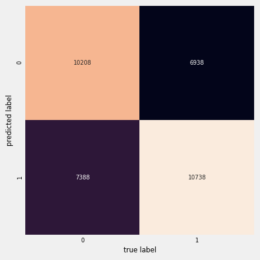

```python
mat = confusion_matrix(ytest,y_pred)
sns.heatmap(mat.T, square=True, annot=True, fmt='d', cbar=False)
plt.xlabel('true label')
plt.ylabel('predicted label')
plt.show()
```

The accuracy of the Decision Tree Classification was 0.59. There was no significant difference between recall, precision, and accuracy score. The training accuracy was higher than Naive Bayes and SVM but still low. It was seen that the model was not trained enough, the model seemed to be underfitting. The highest TN was obtained with this model.

**Visualizing Decision Tree**

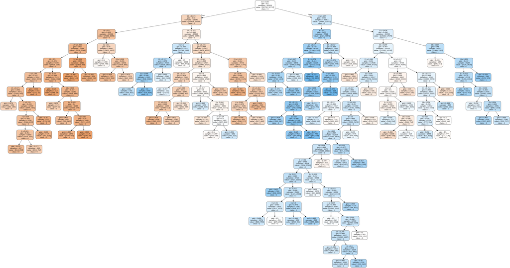

```python
Df_Xtrain=pd.DataFrame(Xtrain)
feature_cols = Df_Xtrain.columns
from sklearn.externals.six import StringIO
from IPython.display import Image
from sklearn.tree import export_graphviz
import pydotplus
dot_data = StringIO()
export_graphviz(model, out_file=dot_data,
                filled=True, rounded=True,
                special_characters=True, feature_names = feature_cols,class_names=['0','1'])
graph = pydotplus.graph_from_dot_data(dot_data.getvalue())
graph.write_png('diabetes.png')
Image(graph.create_png())
```

**Random Forest Classification**

To avoid overfitting, the min_samples_split and min_samples_leaf values were changed and tried with Grid Search like Decision Tree Classification. On parameter tuning, the domain search was based on.

```python
from sklearn.ensemble import RandomForestClassifier
from sklearn.model_selection import GridSearchCV
tuned_parameters= {'criterion': ['entropy','gini'],
                   'min_samples_split': [40,100,200],
                   'min_samples_leaf':[9,20,40],
                   'n_jobs':[4],
                   'n_estimators':[100],
                   'random_state':[1]}
grid=GridSearchCV(RandomForestClassifier(),tuned_parameters,cv=3)
grid.fit(Xtrain, ytrain)
print(grid.best_params_)
model=grid.best_estimator_
y_pred=model.predict(Xtest)
```

```
{'criterion': 'entropy', 'min_samples_leaf': 20, 'min_samples_split': 100, 'n_estimators': 100, 'n_jobs': 4, 'random_state': 1}
```

```python
print(metrics.classification_report(ytest,y_pred))
```

```
              precision    recall  f1-score   support

         0.0       0.62      0.53      0.57     17596
         1.0       0.59      0.68      0.63     17676

    accuracy                           0.61     35272
   macro avg       0.61      0.61      0.60     35272
weighted avg       0.61      0.61      0.60     35272
```

```python
y_pred_train=model.predict(Xtrain)
print(metrics.classification_report(ytrain,y_pred_train))
```

```
              precision    recall  f1-score   support

         0.0       0.73      0.63      0.68     32792
         1.0       0.67      0.76      0.72     32712

    accuracy                           0.70     65504
   macro avg       0.70      0.70      0.70     65504
weighted avg       0.70      0.70      0.70     65504
```

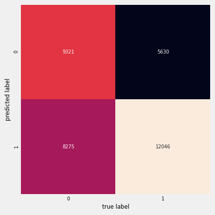

```python
mat = confusion_matrix(ytest,y_pred)
sns.heatmap(mat.T, square=True, annot=True, fmt='d', cbar=False)
plt.xlabel('true label')
plt.ylabel('predicted label')
plt.show()
```

The accuracy of the Random Forest Classification was 0.61. There was a difference between non-churn and churn customers in terms of recall. This model was more prone to churn (1) predictions like Naive Bayes and SVM. The test accuracy was higher than the Decision Tree Classification. The reasons may be that Random Forest works with more than one decision tree and the dataset is complex. Additionally, the difference between train and test accuracy was high for this model.

**AdaBoostClassifier**

```python
from sklearn.ensemble import AdaBoostClassifier
tuned_parameters= {'algorithm':['SAMME', 'SAMME.R'],
                   'n_estimators':[100],
                   'learning_rate': [0.60,0.75,0.8]}
grid=GridSearchCV(AdaBoostClassifier(),tuned_parameters,cv=3)
grid.fit(Xtrain, ytrain)
print(grid.best_params_)
model=grid.best_estimator_
y_pred=model.predict(Xtest)
```

```
{'algorithm': 'SAMME.R', 'learning_rate': 0.75, 'n_estimators': 100}
```

```python
print(metrics.classification_report(ytest,y_pred))
```

```
              precision    recall  f1-score   support

         0.0       0.61      0.55      0.58     17596
         1.0       0.59      0.65      0.62     17676

    accuracy                           0.60     35272
   macro avg       0.60      0.60      0.60     35272
weighted avg       0.60      0.60      0.60     35272
```

```python
y_pred_train=model.predict(Xtrain)
print(metrics.classification_report(ytrain,y_pred_train))
```

```
              precision    recall  f1-score   support

         0.0       0.61      0.55      0.58     32792
         1.0       0.59      0.65      0.62     32712

    accuracy                           0.60     65504
   macro avg       0.60      0.60      0.60     65504
weighted avg       0.60      0.60      0.60     65504
```

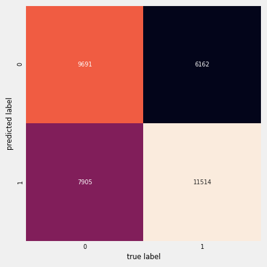

```python
mat = confusion_matrix(ytest,y_pred)
sns.heatmap(mat.T, square=True, annot=True, fmt='d', cbar=False)
plt.xlabel('true label')
plt.ylabel('predicted label')
plt.show()
```

The accuracy of the AdaBoostClassifier was 0.60. The difference between non-churn and churn customers in terms of recall was more stable compare to the other ensemble models. The model had low training accuracy. The model was not trained enough, the model seemed to be underfitting too.

**XGBoost Classifier**

```python
from xgboost import XGBClassifier
tuned_parameters= {'n_estimators':[100,300,500],
                   'learning_rate': [0.1,0.13,0.15]}
grid=GridSearchCV(XGBClassifier(),tuned_parameters,cv=3)
grid.fit(Xtrain, ytrain)
print(grid.best_params_)
model=grid.best_estimator_
y_pred=model.predict(Xtest)
```

```
{'learning_rate': 0.13, 'n_estimators': 300}
```

```python
print(metrics.classification_report(ytest,y_pred))
```

```
              precision    recall  f1-score   support

         0.0       0.62      0.53      0.57     17596
         1.0       0.59      0.68      0.63     17676

    accuracy                           0.61     35272
   macro avg       0.61      0.61      0.60     35272
weighted avg       0.61      0.61      0.60     35272
```

```python
y_pred_train=model.predict(Xtrain)
print(metrics.classification_report(ytrain,y_pred_train))
```

```
              precision    recall  f1-score   support

         0.0       0.65      0.55      0.60     32792
         1.0       0.61      0.70      0.65     32712

    accuracy                           0.63     65504
   macro avg       0.63      0.63      0.62     65504
weighted avg       0.63      0.63      0.62     65504
```

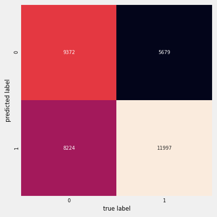

```python
mat = confusion_matrix(ytest,y_pred)
sns.heatmap(mat.T, square=True, annot=True, fmt='d', cbar=False)
plt.xlabel('true label')
plt.ylabel('predicted label')
plt.show()
```

The accuracy of the XGBoost Classifier was 0.61. The difference between non-churn and churn customers in terms of recall was significant compare to the AdaBoostClassifier. The model had as low training accuracy as others.

**Conclusion & Discussion**

In this project, the classification models were used for prediction. In further analysis, more values may be tried in Grid Search parts to obtain more accurate models. Additionally, different feature derivations can be tried to increase model training accuracy. Besides, the missing values can be filled with other methods such as forward or backward fill.

**References**

- https://www.datacamp.com/community/tutorials/decision-tree-classification-python
- https://www.kaggle.com/abhinav89/telecom-customer
- https://aybikedilek.github.io/mef04-AybikeDilek/SPAM-Detection-with-ML-Algorithms.html
- https://towardsdatascience.com/how-machine-learning-can-help-with-customer-retention-6b5bf654e822
- https://scikit-learn.org/stable/modules/generated/sklearn.svm.SVC.html
- https://medium.com/all-things-ai/in-depth-parameter-tuning-for-svc-758215394769
- S. A. Qureshi, A. S. Rehman, A. M. Qamar, A. Kamal and A. Rehman, "Telecommunication subscribers' churn prediction model using machine learning," Eighth International Conference on Digital Information Management (ICDIM 2013), Islamabad, Pakistan, 2013, pp. 131-136, doi: 10.1109/ICDIM.2013.6693977.
- http://library2.smu.ca/bitstream/handle/01/22018/yu_wei_masters_2005.PDF?sequence=1
- https://www.kaggle.com/swapnamandava/notebookd98d835f40/execution
- https://www.kaggle.com/axelalemn/prediccion-de-churn-con-r
- https://www.kaggle.com/aliasgherman/telecom-customer/execution

**Appendix**

1) The explanations of the columns were shared on the metadata file.

```python
pd.set_option('display.max_rows', None)
metadata=pd.read_excel("churn_metadata.xlsx")
```

```python
print(metadata)
```

```
        Column Name   ...                                        Description
0        Customer_ID  ...                                        Customer ID
1           rev_Mean  ...               Mean monthly revenue (charge amount)
2           mou_Mean  ...              Mean number of monthly minutes of use
3        totmrc_Mean  ...                Mean total monthly recurring charge
4            da_Mean  ...            Mean number of directory assisted calls
5        ovrmou_Mean  ...                        Mean overage minutes of use
6        ovrrev_Mean  ...                               Mean overage revenue
7        vceovr_Mean  ...                      Mean revenue of voice overage
8        datovr_Mean  ...                       Mean revenue of data overage
9          roam_Mean  ...                       Mean number of roaming calls
10        change_mou  ...  Percentage change in monthly minutes of use vs...
11        change_rev  ...  Percentage change in monthly revenue vs previo...
12     drop_vce_Mean  ...        Mean number of dropped (failed) voice calls
13     drop_dat_Mean  ...         Mean number of dropped (failed) data calls
```

[output cut: 88 more lines]

2) The following line was used to get an HTML output.

```python
!jupyter nbconvert --to html Churn_Prediction.ipynb
```